# Tail index inference

Gloria Buriticá

This tutorial reviews statistical methods from extreme value theory for risk assessment. Quantifying risk is crucial in numerous engineering, econometric or climate science applications to prevent the societal, economic and environmental consequences of hazards. For example, hydrologists carefully analyse extreme precipitation periods because these can lead to flooding or land sliding, and for this reason, their reports are essential for policymakers. Daily precipitation amounts have been collected systematically in Europe only since the late last century. Therefore, to determine the maximum of daily rain that will be recorded in the next 30 years we propose to use the tools is extreme value theory.

#### Fisher-Tipett-Gnedenko Theorem

Let’s say that we sample $X_1, \dots, X_n$, independent and identically distributed (iid) values from a univariate distribution $F$.

**Theorem.** (Fisher-Tipett-Gnedenko) Assume there exists renormalizing constants $a_n>0,b_n \in \mathbb{R}$ and a non-degenerate distribution $G{\gamma}$ such that
$$\lim_{n \to + \infty}
Pr \left( \max_{t=1,\dots,n} X_t \le x\,a_n + b_n\right) \;=\; G(x),
\quad x \in \mathbb{R},$$
then G belongs to the family of generalized extreme value distributions and
$$G(x)\;= \; G_{\gamma}(x; \mu, \sigma) \; =\; \exp\{ - (1+
\gamma\tfrac{(x-\mu)}{\sigma})_{+}^{-1/\gamma}\}, \quad x \in
\mathbb{R}.$$
for $\mu \in \mathbb{R}$, $\sigma > 0$ and $\gamma \in \mathbb{R}$ such as for $\gamma = 0$ we read the above expression as the limit as $\gamma$ approaches zero. In this case we say that $F$ belong to the **maximum domain of attraction** of $G_{\gamma}$.

Some examples of heavy-tailed distributions are the Pareto, the t-student, the Burr or the Fréchet distribution.

### Estimation of the tail-index

In what follows, we review how to estimate the tail-index from a sample $X_1, \dots, X_n$ of iid observations using the Hill-type estimators. For stationary time series with short-range dependence, these estimators still yield good results in general. First, we start by loading the $\texttt{tsExtremes}$ package.

```r
library(tsExtremes)
```

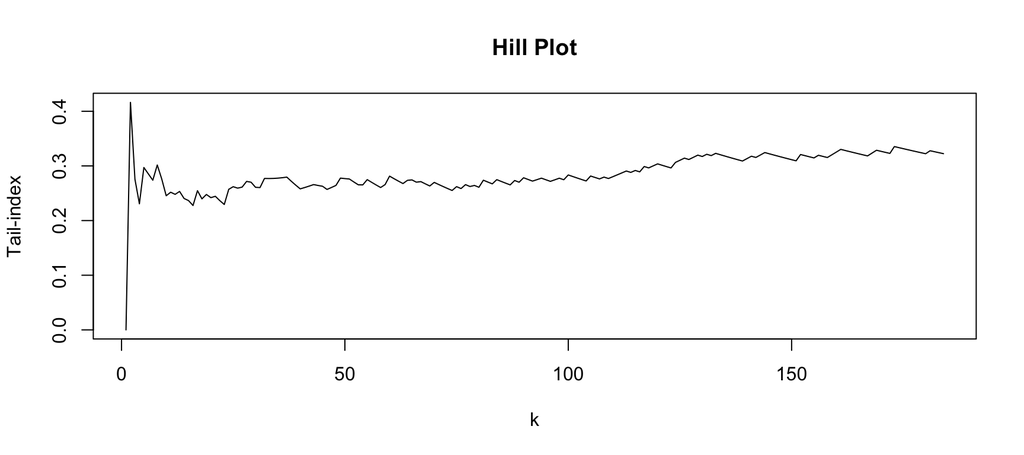

```r
h <- hillestimator(rainfall$BREST[rainfall$SEASON=="SPRING"], plot=T)
```

An unbiased Hill estimator can be obtained running the lines below.

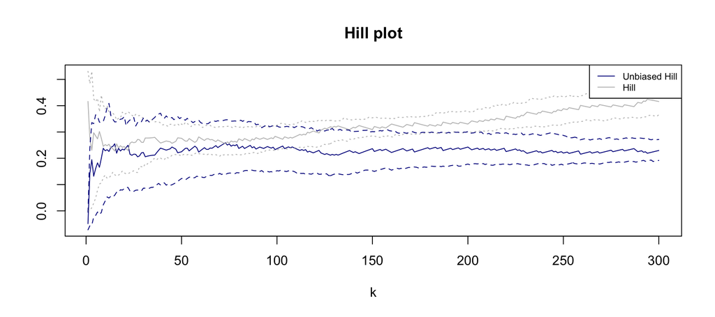

```r
h <- alphaestimator(rainfall$BREST[rainfall$SEASON=="SPRING"], plot=TRUE , R0 = 100,  hill=T ,  k1 = 300 )
```